# Mejora modelo clasificación de vulnerabilidadesB

Pau Susin Alsina & Pau Guàrdia Sabartés

2023-03-25

### 0.0.1 Normalización de las muestras

El modelo principalmente consiste en encontrar las palabras que más se repiten dentro del campo diagnosis de la base de datos de Qualys, des de el que vamos a intentar predecir si la vulnerabilidad se puede considerar crítica o no solamente leyendo dicho parámetro. Para hacerlo el modelo encuentra las palabras con mayor freqüencia dentro del campo nombrado anteriormente y aprende sobre ellas. Este hecho nos lleva a pensar que si intentamos normalizar las palabras dentro del propio campo, se puedan conseguir mayores resultados.

Se ha intentado normalizar todas las palabras que se han encontrado parecidas pero el modelo solo mejora sus resultados con la normalizacion de todos los codigos CVE. Mejora del 1%.

Quizás uno de los metodos que se podria usar seria la implementación de un modelo K-means para clusterizar el máximo de palabras posibles de forma dinàmica.

##Muestras de entreno El objetico de este punto es evaluar el % de muestras criticas a usar a la hora de entrenar el modelo. Observando la base de datos de Qualys nos damos cuenta que existen muchas más vulnerabilidades definidas como no críticas que aquellas definidas como críticas. Por lo que seguramente el porcentaje de muestras críticas usadas para el entreno debe ser menor al de no críticas.

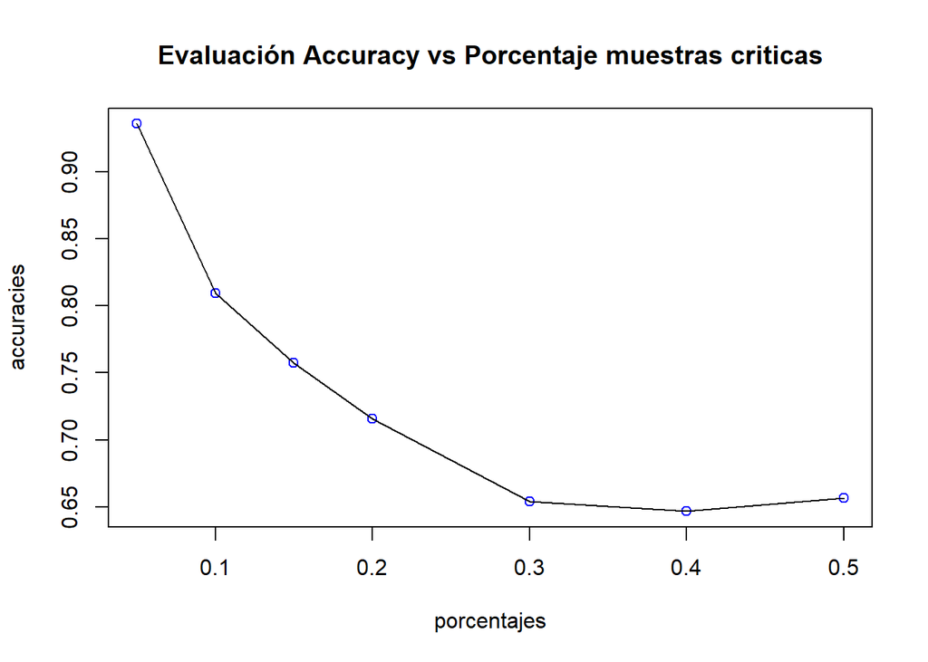

##Optimizar los parámetros del modelo

##Modificación del modelo (n-gramas) En vez de utilizar palabras para la detección, usar la concanetación de palabras.